# Vota Unicamp!

Amanda, Bruno, Mariana, Melissa, Tamilyn e Yasmine

# Introdução

Em meio à crise em que o Brasil se encontra, a educação foi afetada com cortes de orçamento e, infelizmente, isso inclui as Universidades.  
Diante disso, o movimento grevista tem tomado conta da Unicamp e, com isso, a greve foi decidida por meio de assembleias estudantis. Contudo, muito se questiona a respeito da representatividade das decisões tomadas, uma vez que existe pouca adesão.  
Com intuito de verificar qual a opinião da classe estudantil, foi criado o site “https://votaunicamp.herokuapp.com/” para que os alunos matriculados tanto em cursos de graduação e pós graduação votassem e, se quisessem, justificassem o voto.

# Objetivos

Temos o intuito de estudar o comportamento da classe dos estudantes em relação à greve, como por exemplo, se existe uma relação entre a área de estudo e o voto. Assim, podemos caracterizar o perfil do aluno como favorável ou contrário à mobilização.

# Metodologia

## Formatação de Dados

Extraímos do site uma tabela com o número de votos de cada curso (sim, não ou abstenho), incluindo os cursos da Unicamp dos campus Limeira e Piracicaba.  
Abaixo, algumas observações da tabela:

| Curso | Total | Sim | Abstenções | Não |
| --- | --- | --- | --- | --- |
| 1 - Matemática | 3 | 2 (66.7%) | 0 (0.0%) | 1 (33.3%) |
| 1 - Mestrado em Matemática | 1 | 0 (0.0%) | 0 (0.0%) | 1 (100.0%) |
| 10 - Engenharia Mecânica | 40 | 10 (25.0%) | 0 (0.0%) | 30 (75.0%) |
| 10 - Mestrado em Engenharia Mecânica | 4 | 2 (50.0%) | 0 (0.0%) | 2 (50.0%) |
| 100 - Ciências do Esporte | 2 | 0 (0.0%) | 0 (0.0%) | 2 (100.0%) |
| 101 - Engenharia de Manufatura | 3 | 0 (0.0%) | 0 (0.0%) | 3 (100.0%) |

## Proporções

### Proporções por instituto

| instituto | psim | pnao | pabs |
| --- | --- | --- | --- |
| FCA | 0.0000000 | 1.0000000 | 0.0000000 |
| IFGW | 0.3846154 | 0.4358974 | 0.1794872 |
| FEM | 0.3174603 | 0.6825397 | 0.0000000 |
| IB | 0.3333333 | 0.5952381 | 0.0714286 |
| FEEC | 0.1568627 | 0.8235294 | 0.0196078 |
| FEC | 0.3888889 | 0.6111111 | 0.0000000 |

A Tabela 2 pode ser encontrada em *Apêndice*.

## Análises Exploratórias

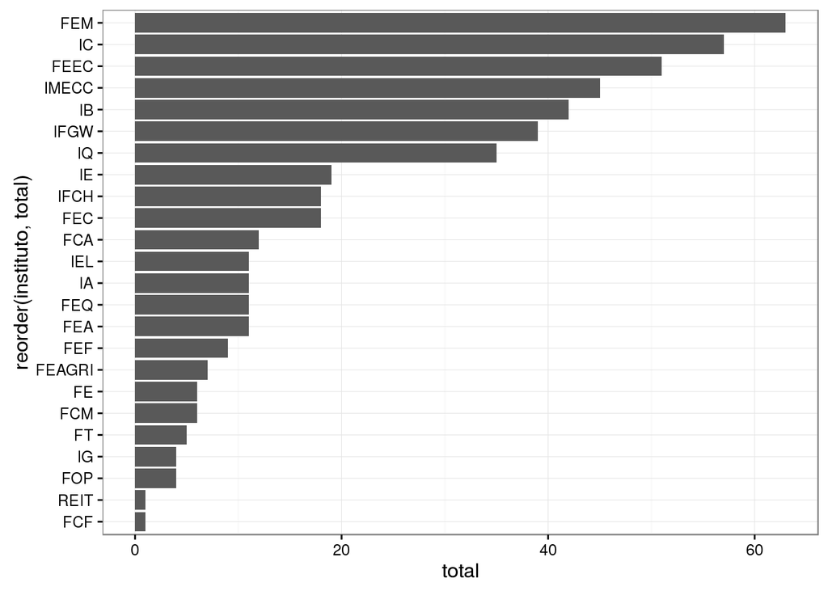

Gráfico do total de votos por instituto

Na tabela abaixo temos mais detalhadamente os votos de alguns institutos.

| Instituto | Não | Sim | Abstenções | Total |
| --- | --- | --- | --- | --- |
| FCA | 12 | 0 | 0 | 12 |
| IFGW | 17 | 15 | 7 | 39 |
| FEM | 43 | 20 | 0 | 63 |
| IB | 25 | 14 | 3 | 42 |
| FEEC | 42 | 8 | 1 | 51 |
| FEC | 11 | 7 | 0 | 18 |

## Estimador Para a Proporção

Uma maneira de estimar a proporção para a população de alunos da Unicamp é através do estimador de *Bootstrap*. Para isso consideraremos os alunos que votaram no site uma amostra da população.

Estimamos que a proporção de alunos contrários à greve corresponde a 67%. Lembrando que essa estimativa considera que os alunos votantes são uma amostra aleatória da população.

## Análise de Cluster

Como alunos, sabemos que existe uma divergência de opinião em função do instituto a que pertence.  
Sendo assim, é normal questionar-se se existe institutos com mesma opinião. Vamos avaliar essa diferença usando um gráfico de componentes, como segue:

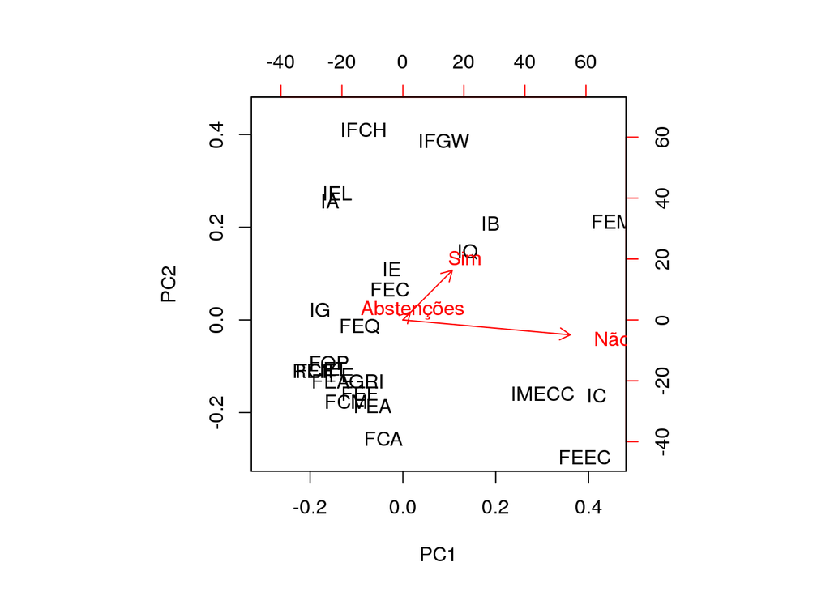

Gráfico de Componentes para Institutos

Ao realizarmos análise de cluster por meio de um dendograma utilizando o Índice de *Bray-Curtis*. Este indicador calcula a similaridade entre os institutos, e pertence ao intervalo $[0,1]$. Quanto mais próximo de 0, a semelhança é maior entre os institutos, uma vez que o índice calcula a “distância” entre grupos.

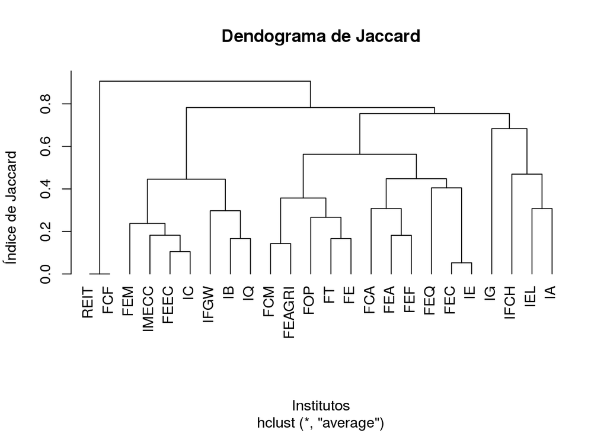

Dendograma de Cluster

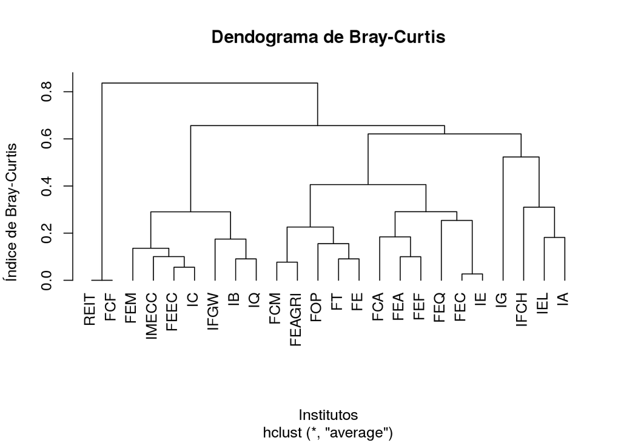

Dendograma de Cluster

# Apêndice

Tabela 1: Tabela com os dados extraídos do site

| Curso | Total | Sim | Abstenções | Não |
| --- | --- | --- | --- | --- |
| 1 - Matemática | 3 | 2 (66.7%) | 0 (0.0%) | 1 (33.3%) |
| 1 - Mestrado em Matemática | 1 | 0 (0.0%) | 0 (0.0%) | 1 (100.0%) |
| 10 - Engenharia Mecânica | 40 | 10 (25.0%) | 0 (0.0%) | 30 (75.0%) |
| 10 - Mestrado em Engenharia Mecânica | 4 | 2 (50.0%) | 0 (0.0%) | 2 (50.0%) |
| 100 - Ciências do Esporte | 2 | 0 (0.0%) | 0 (0.0%) | 2 (100.0%) |
| 101 - Engenharia de Manufatura | 3 | 0 (0.0%) | 0 (0.0%) | 3 (100.0%) |

Tabela 2:

| instituto | psim | pnao | pabs |
| --- | --- | --- | --- |
| FCA | 0.0000000 | 1.0000000 | 0.0000000 |
| IFGW | 0.3846154 | 0.4358974 | 0.1794872 |
| FEM | 0.3174603 | 0.6825397 | 0.0000000 |
| IB | 0.3333333 | 0.5952381 | 0.0714286 |
| FEEC | 0.1568627 | 0.8235294 | 0.0196078 |
| FEC | 0.3888889 | 0.6111111 | 0.0000000 |